# Multiexperiments · Corleone.jl

## Lotka-Volterra Multiexperiments

`CorleoneOED` also provides features to optimize multiple experiments at once. This page shows how to do this, again with the example of the Lotka-Volterra system shown before in the OED example.

## Setup

We will use `Corleone` and `CorleoneOED`to model the optimal experimental design problem with multiple experiments optimized simultaneously.

```julia
using Corleone, CorleoneOED
```

Additionally, we will need the following packages

- `LuxCore` and `Random` for basic setup functions
- `OrdinaryDiffEqTsit5` as an adaptive solver for the related ODEProblem
- `SymbolicIndexingInterface` to conveniently access variables and controls of the solution
- `Optimization`, `OptimizationMOI`, `Ipopt`, and `ComponentArrays` to setup and solve the optimization problem
- `CairoMakie` to plot the solution

```julia
using LuxCore
using Random
using OrdinaryDiffEqTsit5
using SymbolicIndexingInterface
using Optimization
using OptimizationMOI
using Ipopt
using ComponentArrays
using CairoMakie
```

## Lotka Volterrra Dynamics

```julia
function lotka_dynamics(du, u, p, t)
    du[1] = u[1] - p[2] * prod(u[1:2]) - 0.4 * p[1] * u[1]
    du[2] = -u[2] + p[3] * prod(u[1:2]) - 0.2 * p[1] * u[2]
    return
end
tspan = (0.0, 12.0)
u0 = [0.5, 0.7]
p0 = [0.0, 1.0, 1.0]
prob = ODEProblem(lotka_dynamics, u0, tspan, p0)
```

```
ODEProblem with uType Vector{Float64} and tType Float64. In-place: true
Non-trivial mass matrix: false
timespan: (0.0, 12.0)
u0: 2-element Vector{Float64}:
 0.5
 0.7
```

## Construct the `MultiExperimentLayer`

For designing multiple experiments at once, `CorleoneOED` provides the `MultiExperimentLayer`. It can be constructed analogous to the `OEDLayer` from an `ODEProblem` and a suitable algorithm, with an additional integer specifying the number of experiments to optimize. In this case we want to design two experiments.

```julia
cgrid = collect(0.0:0.25:11.75)
control = ControlParameter(
    cgrid, name = :fishing, bounds = (0.0, 1.0)
)

multi_exp = MultiExperimentLayer{false}(
    prob, Tsit5(), 2;
    params = [2, 3],
    bounds_p = ([1.0, 1.0], [1.0, 1.0]),
    controls = (1 => control,),
    measurements = [
        ControlParameter(cgrid, controls = ones(48), bounds = (0.0, 1.0)),
        ControlParameter(cgrid, controls = ones(48), bounds = (0.0, 1.0)),
    ],
    observed = (u, p, t) -> u[1:2]
)
```

```
MultiExperimentLayer with continuous measurement model and 2 experiments.
```

Calling this layer with the appropriate arguments integrates the two experiments. We can define a plotting function and look at the initial experiments for the initial values provided above.

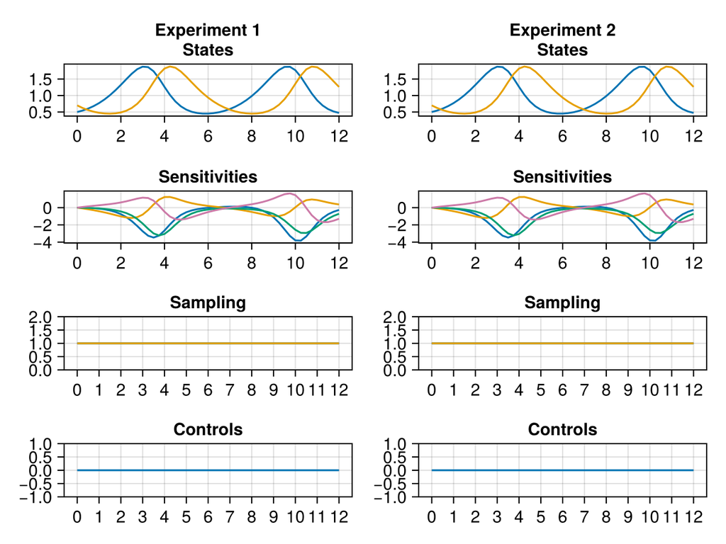

```julia
function plot_experiments(sols)
    f = Figure()
    for (i, sol) in enumerate(sols)
        ax = CairoMakie.Axis(f[1, i], xticks = 0:2:12, title = "Experiment $i\nStates")
        ax2 = CairoMakie.Axis(f[2, i], xticks = 0:2:12, title = "Sensitivities")
        ax3 = CairoMakie.Axis(f[3, i], xticks = 0:1:12, title = "Sampling")
        ax4 = CairoMakie.Axis(f[4, i], xticks = 0:1:12, title = "Controls")
        plot!(ax, sol, idxs = [1, 2])
        plot!(ax2, sol, idxs = collect(values(sol.sys.variables))[startswith.(string.(keys(sol.sys.variables)), "G")])
        stairs!(ax3, sol, vars = [:w₁, :w₂])
        stairs!(ax4, sol, vars = [:p₁])
    end
    return f
end
ps, st = LuxCore.setup(Random.default_rng(), multi_exp)

sols, _ = multi_exp(nothing, ps, st)
plot_experiments(sols)
```

## Set up and solve the problem

The problem is set up like the single experiment problem by providing a suitable criterion and an upper bound on the measurements. Here, we take the `ACriterion`, i.e., the trace of the inverse of the Fisher information matrix.

```julia
optprob = OptimizationProblem(
    multi_exp, ACriterion(); M = zeros(4) .+ 4.0
)

uopt = solve(
    optprob, Ipopt.Optimizer(),
    tol = 1.0e-7,
    hessian_approximation = "limited-memory",
    max_iter = 300
);
```

```
This is Ipopt version 3.14.19, running with linear solver MUMPS 5.8.2.

Number of nonzeros in equality constraint Jacobian...:        0
Number of nonzeros in inequality constraint Jacobian.:     1152
Number of nonzeros in Lagrangian Hessian.............:        0

Total number of variables............................:      288
                     variables with only lower bounds:        0
                variables with lower and upper bounds:      288
                     variables with only upper bounds:        0
Total number of equality constraints.................:        0
Total number of inequality constraints...............:        4
        inequality constraints with only lower bounds:        0
   inequality constraints with lower and upper bounds:        4
        inequality constraints with only upper bounds:        0

iter    objective    inf_pr   inf_du lg(mu)  ||d||  lg(rg) alpha_du alpha_pr  ls
   0  2.7087225e-02 7.88e+00 1.07e-03   0.0 0.00e+00    -  0.00e+00 0.00e+00   0
   1  3.1105972e-01 0.00e+00 5.73e-02  -0.0 2.13e+00    -  3.23e-02 1.00e+00f  1
   2  2.9769938e-01 0.00e+00 4.90e-03  -2.3 4.75e-02    -  9.55e-01 1.00e+00f  1
   3  2.1836282e-01 0.00e+00 1.27e-02  -2.8 3.24e-01    -  8.57e-01 1.00e+00f  1
   4  1.6117025e-01 0.00e+00 1.39e-02  -3.3 4.50e-01    -  1.00e+00 1.00e+00f  1
   5  9.8785313e-02 0.00e+00 6.33e-03  -3.4 1.64e+00    -  9.73e-01 8.66e-01f  1
   6  5.9813700e-02 0.00e+00 2.15e-03  -3.3 7.59e-01    -  7.51e-01 6.63e-01f  1
   7  4.1756751e-02 0.00e+00 2.56e-03  -3.7 2.55e-01    -  9.32e-01 1.00e+00f  1
   8  3.1680495e-02 0.00e+00 7.23e-04  -4.2 2.70e-01    -  9.85e-01 8.96e-01f  1
   9  2.6641927e-02 0.00e+00 3.97e-04  -4.6 3.67e-01    -  9.75e-01 8.04e-01f  1
iter    objective    inf_pr   inf_du lg(mu)  ||d||  lg(rg) alpha_du alpha_pr  ls
  10  2.4074046e-02 0.00e+00 3.62e-04  -5.0 5.81e-01    -  9.89e-01 5.39e-01f  1
  11  2.2890669e-02 0.00e+00 2.93e-04  -5.2 8.16e-01    -  9.95e-01 2.52e-01f  1
  12  2.1522939e-02 0.00e+00 3.43e-04  -4.8 1.10e+00    -  1.00e+00 4.47e-01f  1
  13  2.1112574e-02 0.00e+00 1.89e-04  -4.9 1.95e-01    -  9.88e-01 1.00e+00f  1
  14  2.0319317e-02 0.00e+00 1.39e-04  -5.1 6.98e-01    -  9.87e-01 8.07e-01f  1
  15  1.9819966e-02 0.00e+00 1.19e-04  -5.3 4.52e-01    -  9.90e-01 7.45e-01f  1
  16  1.9454870e-02 0.00e+00 1.74e-04  -5.5 4.12e-01    -  1.00e+00 8.32e-01f  1
  17  1.9131312e-02 0.00e+00 5.61e-05  -5.8 6.15e-01    -  9.97e-01 6.77e-01f  1
  18  1.9284648e-02 0.00e+00 7.69e-05  -5.5 3.87e-01    -  1.00e+00 1.00e+00f  1
  19  1.9156537e-02 0.00e+00 4.60e-05  -5.6 1.44e-01    -  1.00e+00 1.00e+00f  1
iter    objective    inf_pr   inf_du lg(mu)  ||d||  lg(rg) alpha_du alpha_pr  ls
  20  1.9148164e-02 0.00e+00 4.49e-05  -5.6 1.19e-01    -  1.00e+00 1.00e+00f  1
  21  1.9149661e-02 0.00e+00 2.77e-05  -5.6 5.40e-02    -  1.00e+00 1.00e+00f  1
  22  1.9150438e-02 0.00e+00 2.18e-05  -5.6 3.68e-02    -  1.00e+00 1.00e+00f  1
  23  1.9131623e-02 0.00e+00 6.70e-04  -8.0 1.39e-03    -  1.00e+00 1.00e+00f  1
  24  1.8976114e-02 0.00e+00 1.78e-04  -8.0 1.29e-01    -  1.00e+00 7.29e-02f  1
  25  1.8890273e-02 0.00e+00 9.48e-05  -8.4 2.50e-01    -  1.00e+00 6.74e-02f  1
  26  1.8827664e-02 0.00e+00 7.51e-05  -8.7 4.31e-01    -  1.00e+00 7.46e-02f  1
  27  1.8768488e-02 0.00e+00 9.89e-05  -7.7 2.29e+00    -  1.00e+00 3.00e-02f  1
  28  1.8709197e-02 0.00e+00 3.31e-05  -7.2 1.30e+00    -  1.00e+00 1.09e-01f  1
  29  1.8650545e-02 0.00e+00 4.57e-05  -6.8 9.10e-01    -  1.00e+00 2.24e-01f  1
iter    objective    inf_pr   inf_du lg(mu)  ||d||  lg(rg) alpha_du alpha_pr  ls
  30  1.8638511e-02 0.00e+00 4.29e-04  -8.7 9.12e-04    -  1.00e+00 1.00e+00f  1
  31  1.8620732e-02 0.00e+00 7.25e-05  -9.7 5.50e-02    -  1.00e+00 7.00e-02f  1
  32  1.8605785e-02 0.00e+00 4.74e-05  -8.3 5.69e-01    -  1.00e+00 3.48e-02f  1
  33  1.8593635e-02 0.00e+00 1.26e-04  -7.2 6.37e+00    -  1.00e+00 5.85e-03f  1
  34  1.8557344e-02 0.00e+00 1.21e-04  -6.6 5.13e+00    -  1.00e+00 6.95e-02f  1
  35  1.8551303e-02 0.00e+00 1.45e-04  -6.4 1.59e+00    -  1.00e+00 9.43e-02f  1
  36  1.8627050e-02 0.00e+00 1.17e-04  -6.2 3.91e-01    -  1.00e+00 8.36e-01f  1
  37  1.8624991e-02 0.00e+00 9.37e-03  -6.3 9.51e-03    -  1.00e+00 1.00e+00f  1
  38  1.8618909e-02 0.00e+00 6.89e-03  -6.3 6.20e-01    -  2.65e-01 1.49e-01f  2
  39  1.8580714e-02 0.00e+00 9.32e-05  -6.3 2.89e-01    -  1.00e+00 1.00e+00f  1
iter    objective    inf_pr   inf_du lg(mu)  ||d||  lg(rg) alpha_du alpha_pr  ls
  40  1.8520548e-02 0.00e+00 1.87e-04  -6.3 1.29e+00    -  2.02e-01 5.28e-01f  1
  41  1.8785838e-02 0.00e+00 2.94e-05  -5.7 2.29e+00    -  5.06e-01 4.37e-01f  1
  42  1.8667083e-02 0.00e+00 2.41e-04  -6.0 1.02e+00    -  4.91e-02 8.46e-01f  1
  43  1.8642756e-02 0.00e+00 2.77e-01  -6.0 2.77e-01    -  1.00e+00 1.00e+00f  1
  44  1.8573876e-02 0.00e+00 1.80e-01  -6.0 8.90e-01    -  3.49e-01 1.87e-01f  1
  45  1.8442549e-02 0.00e+00 5.91e-02  -6.0 9.86e-01    -  6.73e-01 4.49e-01f  1
  46  1.8671682e-02 0.00e+00 6.93e-04  -5.5 7.12e-01    -  9.88e-01 7.33e-01f  1
  47  1.8672243e-02 0.00e+00 3.40e-04  -5.6 3.41e-04    -  1.00e+00 1.00e+00f  1
  48  1.8596932e-02 0.00e+00 2.41e-04  -5.6 3.42e-01    -  1.00e+00 9.18e-01f  1
  49  1.8544066e-02 0.00e+00 1.60e-04  -5.6 7.69e-01    -  5.64e-01 6.69e-01f  1
iter    objective    inf_pr   inf_du lg(mu)  ||d||  lg(rg) alpha_du alpha_pr  ls
  50  1.8527192e-02 0.00e+00 1.83e-04  -5.6 3.92e-01    -  1.00e+00 1.98e-01f  1
  51  1.8484177e-02 0.00e+00 2.04e-04  -5.6 3.28e-01    -  1.00e+00 1.00e+00f  1
  52  1.8482332e-02 0.00e+00 1.70e-04  -5.6 1.70e-04    -  1.00e+00 1.00e+00f  1
  53  1.8424704e-02 0.00e+00 9.24e-05  -5.6 3.24e-02    -  1.00e+00 1.00e+00f  1
  54  1.8277203e-02 0.00e+00 5.55e-05  -6.3 3.84e-02    -  9.98e-01 5.45e-01f  1
  55  1.8099415e-02 0.00e+00 6.54e-05  -6.7 2.45e-01    -  1.00e+00 4.26e-01f  1
  56  1.8038995e-02 0.00e+00 9.66e-05  -5.9 1.03e+00    -  1.00e+00 2.92e-01f  1
  57  1.8136161e-02 0.00e+00 1.75e-04  -5.7 4.87e-01    -  1.00e+00 7.72e-01f  1
  58  1.8118275e-02 0.00e+00 2.11e-04  -5.8 1.66e+00    -  5.85e-01 9.11e-02f  1
  59  1.8076506e-02 0.00e+00 2.49e-04  -5.8 2.73e-01    -  1.00e+00 1.00e+00f  1
iter    objective    inf_pr   inf_du lg(mu)  ||d||  lg(rg) alpha_du alpha_pr  ls
  60  1.8059993e-02 0.00e+00 2.43e-04  -5.8 1.69e-01    -  1.00e+00 1.00e+00f  1
  61  1.8051965e-02 0.00e+00 2.29e-04  -5.8 1.40e-01    -  1.00e+00 1.00e+00f  1
  62  1.8050021e-02 0.00e+00 2.14e-04  -5.8 2.18e-04    -  1.00e+00 1.00e+00f  1
  63  1.8027661e-02 0.00e+00 4.79e-05  -5.8 1.33e-02    -  1.00e+00 1.00e+00f  1
  64  1.7871891e-02 0.00e+00 4.98e-05  -6.7 2.16e-02    -  9.98e-01 1.00e+00f  1
  65  1.7813694e-02 0.00e+00 3.84e-05  -7.0 1.35e-01    -  1.00e+00 3.34e-01f  1
  66  1.7766206e-02 0.00e+00 5.29e-05  -6.3 9.43e-01    -  1.00e+00 2.68e-01f  1
  67  1.7845598e-02 0.00e+00 4.00e-05  -5.9 5.79e-01    -  1.00e+00 3.57e-01f  1
  68  1.7870735e-02 0.00e+00 1.55e-05  -6.0 2.61e-01    -  9.56e-01 1.00e+00f  1
  69  1.7864125e-02 0.00e+00 4.15e-05  -6.0 2.23e-01    -  1.00e+00 1.00e+00f  1
iter    objective    inf_pr   inf_du lg(mu)  ||d||  lg(rg) alpha_du alpha_pr  ls
  70  1.7862671e-02 0.00e+00 3.28e-05  -6.0 1.29e-01    -  1.00e+00 1.00e+00f  1
  71  1.7862837e-02 0.00e+00 4.63e-06  -6.0 6.73e-02    -  1.00e+00 1.00e+00f  1
  72  1.7731473e-02 0.00e+00 1.71e-05  -8.0 2.54e-01    -  4.59e-01 6.30e-01f  1
  73  1.7695893e-02 0.00e+00 8.34e-06  -6.6 3.05e-01    -  1.00e+00 1.00e+00f  1
  74  1.7659425e-02 0.00e+00 8.07e-06  -6.9 1.92e-01    -  9.92e-01 1.00e+00f  1
  75  1.7631201e-02 0.00e+00 1.50e-05  -7.6 2.27e-01    -  1.00e+00 1.00e+00f  1
  76  1.7637095e-02 0.00e+00 1.43e-05  -7.3 1.31e-01    -  1.00e+00 1.00e+00f  1
  77  1.7633638e-02 0.00e+00 9.96e-06  -7.4 1.98e-01    -  1.00e+00 1.00e+00f  1
  78  1.7633635e-02 0.00e+00 7.18e-06  -7.4 2.46e-01    -  6.92e-01 6.25e-02f  5
  79  1.7633639e-02 0.00e+00 1.27e-06  -7.4 1.09e-02    -  1.00e+00 1.00e+00h  1
iter    objective    inf_pr   inf_du lg(mu)  ||d||  lg(rg) alpha_du alpha_pr  ls
  80  1.7633641e-02 0.00e+00 1.23e-06  -7.4 7.47e-03    -  1.00e+00 1.00e+00h  1
  81  1.7633644e-02 0.00e+00 1.88e-07  -7.4 1.18e-03    -  1.00e+00 1.00e+00h  1
  82  1.7624842e-02 0.00e+00 5.57e-06  -8.0 4.60e-02    -  1.00e+00 1.00e+00f  1
  83  1.7622306e-02 0.00e+00 2.32e-06  -9.9 1.46e-02    -  1.00e+00 9.41e-01f  1
  84  1.7622131e-02 0.00e+00 6.57e-07 -11.0 6.39e-03    -  1.00e+00 9.66e-01f  1
  85  1.7622125e-02 0.00e+00 1.55e-07 -11.0 2.47e-03    -  1.00e+00 1.00e+00h  1
  86  1.7622125e-02 0.00e+00 1.01e-07 -11.0 1.15e-03    -  1.00e+00 1.00e+00h  1
  87  1.7622125e-02 0.00e+00 1.51e-08 -11.0 2.51e-04    -  1.00e+00 1.00e+00h  1

Number of Iterations....: 87

                                   (scaled)                 (unscaled)
Objective...............:   1.7622124851998971e-02    1.7622124851998971e-02
Dual infeasibility......:   1.5112744002792385e-08    1.5112744002792385e-08
Constraint violation....:   0.0000000000000000e+00    0.0000000000000000e+00
Variable bound violation:   3.0798565311113662e-09    3.0798565311113662e-09
Complementarity.........:   1.0000000057545575e-11    1.0000000057545575e-11
Overall NLP error.......:   1.5112744002792385e-08    1.5112744002792385e-08


Number of objective function evaluations             = 97
Number of objective gradient evaluations             = 88
Number of equality constraint evaluations            = 0
Number of inequality constraint evaluations          = 97
Number of equality constraint Jacobian evaluations   = 0
Number of inequality constraint Jacobian evaluations = 88
Number of Lagrangian Hessian evaluations             = 0
Total seconds in IPOPT                               = 69.372

EXIT: Optimal Solution Found.
```

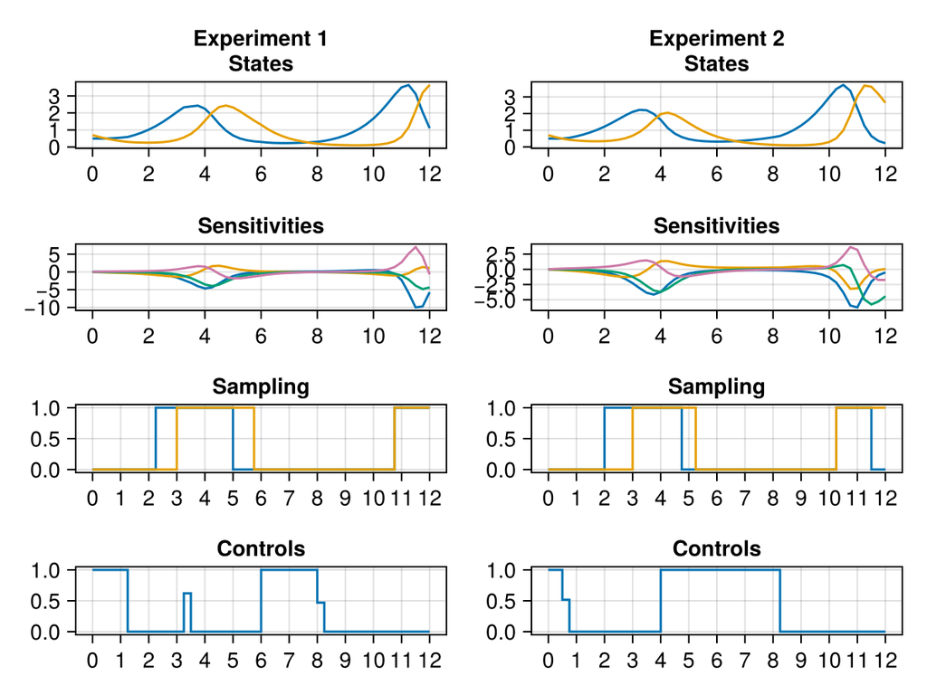

```julia
ps, st = LuxCore.setup(Random.default_rng(), multi_exp)
optsol, _ = multi_exp(nothing, uopt + zero(ComponentArray(ps)), st)

plot_experiments(optsol)
```

## Different parameters per experiment

The `MultiExperimentLayer` can also be used to target different subsets of parameters per experiment. In this case, instead of specifying how many experiments shall be optimized, a vector of experiment-specific parameters must be provided. In the following example, we will design one experiment targeting parameter 2, with the second targeting parameter 3. Of course, also combinations of the parameters can be targeted in each experiment.

```julia
params_per_experiment = [[2], [3]]

split_exp = MultiExperimentLayer{false}(
    prob, Tsit5(), params_per_experiment;
    bounds_p = ([1.0, 1.0], [1.0, 1.0]),
    controls = (1 => control,),
    measurements = [
        ControlParameter(cgrid, controls = ones(48), bounds = (0.0, 1.0)),
        ControlParameter(cgrid, controls = ones(48), bounds = (0.0, 1.0)),
    ],
    observed = (u, p, t) -> u[1:2]
)


optprob = OptimizationProblem(
    split_exp, ACriterion(); M = zeros(4) .+ 4.0
)

uopt = solve(
    optprob, Ipopt.Optimizer(),
    tol = 1.0e-7,
    hessian_approximation = "limited-memory",
    max_iter = 300
);
```

```
This is Ipopt version 3.14.19, running with linear solver MUMPS 5.8.2.

Number of nonzeros in equality constraint Jacobian...:        0
Number of nonzeros in inequality constraint Jacobian.:     1152
Number of nonzeros in Lagrangian Hessian.............:        0

Total number of variables............................:      288
                     variables with only lower bounds:        0
                variables with lower and upper bounds:      288
                     variables with only upper bounds:        0
Total number of equality constraints.................:        0
Total number of inequality constraints...............:        4
        inequality constraints with only lower bounds:        0
   inequality constraints with lower and upper bounds:        4
        inequality constraints with only upper bounds:        0

iter    objective    inf_pr   inf_du lg(mu)  ||d||  lg(rg) alpha_du alpha_pr  ls
   0  5.3987718e-02 7.88e+00 2.90e-03   0.0 0.00e+00    -  0.00e+00 0.00e+00   0
   1  5.8810575e-01 0.00e+00 2.12e-01  -0.0 2.13e+00    -  3.23e-02 1.00e+00f  1
   2  4.9594449e-01 0.00e+00 4.26e-02  -1.5 2.16e-01    -  8.98e-01 1.00e+00f  1
   3  3.5007664e-01 0.00e+00 6.57e-02  -2.0 5.23e-01    -  9.90e-01 1.00e+00f  1
   4  2.1405573e-01 0.00e+00 2.24e-02  -2.6 8.90e-01    -  9.22e-01 1.00e+00f  1
   5  1.3918896e-01 0.00e+00 6.78e-03  -2.9 8.31e-01    -  7.21e-01 6.41e-01f  1
   6  9.1422101e-02 0.00e+00 7.77e-03  -3.1 2.86e-01    -  9.24e-01 1.00e+00f  1
   7  6.6477927e-02 0.00e+00 3.82e-03  -3.5 3.36e-01    -  9.90e-01 1.00e+00f  1
   8  5.6135094e-02 0.00e+00 1.88e-03  -4.0 5.15e-01    -  9.01e-01 5.56e-01f  1
   9  4.9314972e-02 0.00e+00 1.30e-03  -4.1 3.37e-01    -  9.83e-01 5.61e-01f  1
iter    objective    inf_pr   inf_du lg(mu)  ||d||  lg(rg) alpha_du alpha_pr  ls
  10  4.3678550e-02 0.00e+00 2.05e-03  -4.2 4.04e-01    -  9.78e-01 7.58e-01f  1
  11  4.0522434e-02 0.00e+00 9.60e-04  -4.4 3.21e-01    -  9.87e-01 5.64e-01f  1
  12  3.8490298e-02 0.00e+00 8.00e-04  -4.4 1.23e+00    -  9.87e-01 3.40e-01f  1
  13  3.7494059e-02 0.00e+00 9.32e-04  -4.4 3.40e-01    -  9.57e-01 8.34e-01f  1
  14  3.5595535e-02 0.00e+00 9.24e-04  -4.6 5.32e-01    -  9.87e-01 7.64e-01f  1
  15  3.7704167e-02 0.00e+00 1.26e-03  -4.3 2.00e-01    -  1.00e+00 1.00e+00f  1
  16  3.6450794e-02 0.00e+00 7.68e-04  -4.4 1.36e-01    -  1.00e+00 1.00e+00f  1
  17  3.6134711e-02 0.00e+00 6.44e-04  -4.4 8.74e-02    -  1.00e+00 1.00e+00f  1
  18  3.6098961e-02 0.00e+00 2.24e-04  -4.4 1.32e-01    -  1.00e+00 1.00e+00f  1
  19  3.3723766e-02 0.00e+00 9.47e-04  -6.6 4.27e-01    -  5.03e-01 5.66e-01f  1
iter    objective    inf_pr   inf_du lg(mu)  ||d||  lg(rg) alpha_du alpha_pr  ls
  20  3.2556848e-02 0.00e+00 6.05e-04  -5.2 3.47e-01    -  1.00e+00 7.10e-01f  1
  21  3.1686871e-02 0.00e+00 3.13e-04  -5.6 2.02e-01    -  1.00e+00 8.48e-01f  1
  22  3.1440401e-02 0.00e+00 2.27e-04  -5.8 2.67e-01    -  1.00e+00 3.24e-01f  1
  23  3.1248928e-02 0.00e+00 2.62e-04  -5.4 1.72e+00    -  1.00e+00 2.41e-01f  1
  24  3.1474161e-02 0.00e+00 1.73e-04  -5.2 2.99e-01    -  1.00e+00 5.07e-01f  1
  25  3.1410100e-02 0.00e+00 1.66e-04  -5.3 1.08e-01    -  1.00e+00 1.00e+00f  1
  26  3.1390335e-02 0.00e+00 3.41e-05  -5.3 5.97e-02    -  1.00e+00 1.00e+00f  1
  27  3.0921990e-02 0.00e+00 1.40e-04  -8.0 3.78e-01    -  6.07e-01 5.11e-01f  1
  28  3.0739082e-02 0.00e+00 8.68e-05  -6.1 5.35e-01    -  9.99e-01 4.22e-01f  1
  29  3.0559493e-02 0.00e+00 5.24e-05  -6.2 7.04e-01    -  9.95e-01 5.33e-01f  1
iter    objective    inf_pr   inf_du lg(mu)  ||d||  lg(rg) alpha_du alpha_pr  ls
  30  3.0483729e-02 0.00e+00 3.22e-05  -6.1 4.76e-01    -  1.00e+00 6.86e-01f  1
  31  3.0413696e-02 0.00e+00 9.02e-05  -6.4 5.40e-01    -  1.00e+00 6.03e-01f  1
  32  3.0332930e-02 0.00e+00 2.36e-05  -6.8 1.90e-01    -  1.00e+00 8.94e-01f  1
  33  3.0312830e-02 0.00e+00 2.56e-05  -6.8 2.08e-01    -  1.00e+00 8.46e-01f  1
  34  3.0340893e-02 0.00e+00 1.15e-05  -6.6 1.20e-01    -  1.00e+00 1.00e+00f  1
  35  3.0325783e-02 0.00e+00 8.37e-06  -6.7 1.27e-01    -  1.00e+00 1.00e+00f  1
  36  3.0325488e-02 0.00e+00 9.64e-06  -6.7 1.05e-01    -  1.00e+00 5.00e-01f  2
  37  3.0325360e-02 0.00e+00 7.07e-06  -6.7 5.93e-02    -  1.00e+00 5.00e-01f  2
  38  3.0325250e-02 0.00e+00 2.05e-06  -6.7 1.43e-02    -  1.00e+00 1.00e+00h  1
  39  3.0298432e-02 0.00e+00 5.57e-06  -8.0 4.54e-01    -  6.28e-01 4.94e-01f  1
iter    objective    inf_pr   inf_du lg(mu)  ||d||  lg(rg) alpha_du alpha_pr  ls
  40  3.0280869e-02 0.00e+00 3.17e-05  -7.4 4.50e-01    -  1.00e+00 7.59e-01f  1
  41  3.0269784e-02 0.00e+00 2.83e-05  -8.1 2.88e-01    -  1.00e+00 8.67e-01f  1
  42  3.0268093e-02 0.00e+00 3.61e-05  -8.0 1.51e-01    -  1.00e+00 1.00e+00f  1
  43  3.0267077e-02 0.00e+00 1.37e-05  -8.3 5.79e-02    -  1.00e+00 4.03e-01f  1
  44  3.0265486e-02 0.00e+00 1.43e-05  -9.3 4.22e-02    -  1.00e+00 6.57e-01f  1
  45  3.0265152e-02 0.00e+00 5.39e-06 -10.6 3.94e-02    -  1.00e+00 3.24e-01f  1
  46  3.0264653e-02 0.00e+00 5.89e-06  -9.8 3.01e-02    -  1.00e+00 9.20e-01f  1
  47  3.0264561e-02 0.00e+00 2.83e-06 -11.0 1.60e-02    -  1.00e+00 7.50e-01f  1
  48  3.0264808e-02 0.00e+00 1.54e-05  -9.1 1.20e-02    -  1.00e+00 1.00e+00f  1
  49  3.0264709e-02 0.00e+00 3.66e-07  -9.2 1.10e-02    -  1.00e+00 1.00e+00f  1
iter    objective    inf_pr   inf_du lg(mu)  ||d||  lg(rg) alpha_du alpha_pr  ls
  50  3.0264709e-02 0.00e+00 3.14e-07  -9.2 1.09e-03    -  1.00e+00 1.00e+00h  1
  51  3.0264709e-02 0.00e+00 1.37e-07  -9.2 6.36e-04    -  1.00e+00 1.00e+00h  1
  52  3.0264709e-02 0.00e+00 5.82e-08  -9.2 5.22e-04    -  1.00e+00 1.00e+00h  1

Number of Iterations....: 52

                                   (scaled)                 (unscaled)
Objective...............:   3.0264708636954657e-02    3.0264708636954657e-02
Dual infeasibility......:   5.8241752169164735e-08    5.8241752169164735e-08
Constraint violation....:   0.0000000000000000e+00    0.0000000000000000e+00
Variable bound violation:   0.0000000000000000e+00    0.0000000000000000e+00
Complementarity.........:   6.0734698257965359e-10    6.0734698257965359e-10
Overall NLP error.......:   5.8241752169164735e-08    5.8241752169164735e-08


Number of objective function evaluations             = 59
Number of objective gradient evaluations             = 53
Number of equality constraint evaluations            = 0
Number of inequality constraint evaluations          = 59
Number of equality constraint Jacobian evaluations   = 0
Number of inequality constraint Jacobian evaluations = 53
Number of Lagrangian Hessian evaluations             = 0
Total seconds in IPOPT                               = 43.702

EXIT: Optimal Solution Found.
```

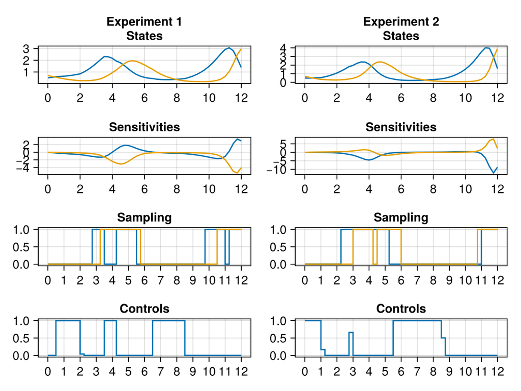

```julia
ps, st = LuxCore.setup(Random.default_rng(), split_exp)
split_sols, _ = split_exp(nothing, uopt + zero(ComponentArray(ps)), st)

plot_experiments(split_sols)
```

## Appendix

**This example was built using these direct dependencies,**

```julia
        using Pkg
        Pkg.status()
```

```
Status `~/work/Corleone.jl/Corleone.jl/docs/Project.toml`
  [13f3f980] CairoMakie v0.15.8
  [b0b7db55] ComponentArrays v0.15.32
  [2751e0db] Corleone v0.0.3 `~/work/Corleone.jl/Corleone.jl`
  [6590a4b1] CorleoneOED v0.0.2
  [e30172f5] Documenter v1.17.0
  [daee34ce] DocumenterCitations v1.4.1
  [d12716ef] DocumenterInterLinks v1.1.0
  [f6369f11] ForwardDiff v1.3.2
  [b6b21f68] Ipopt v1.14.1
  [682c06a0] JSON v1.4.0
  [98b081ad] Literate v2.21.0
  [bb33d45b] LuxCore v1.5.3
  [961ee093] ModelingToolkit v11.13.0
  [7f7a1694] Optimization v5.5.0
  [22f7324a] OptimizationLBFGSB v1.4.0
  [fd9f6733] OptimizationMOI v1.2.0
  [b1df2697] OrdinaryDiffEqTsit5 v1.9.0
  [2efcf032] SymbolicIndexingInterface v0.3.46
  [ddb6d928] YAML v0.4.16
  [9a3f8284] Random v1.11.0
```

**and using this machine and Julia version.**

```julia
        using InteractiveUtils
        InteractiveUtils.versioninfo()
```

```
Julia Version 1.12.5
Commit 5fe89b8ddc1 (2026-02-09 16:05 UTC)
Build Info:
  Official https://julialang.org release
Platform Info:
  OS: Linux (x86_64-linux-gnu)
  CPU: 4 × AMD EPYC 7763 64-Core Processor
  WORD_SIZE: 64
  LLVM: libLLVM-18.1.7 (ORCJIT, znver3)
  GC: Built with stock GC
Threads: 1 default, 1 interactive, 1 GC (on 4 virtual cores)
```

**A more complete overview of all dependencies and their versions is also provided.**

```julia
        using Pkg
        Pkg.status(; mode = PKGMODE_MANIFEST)
```

[output not shown]

[output not shown]

*This page was generated using Literate.jl.*